# Analysis of Mental Health in the Tech Industry in the United States

A data science project by Maya Kaplan

### Introduction

The objective of this project is to analyse survey data regarding people who work in tech and their relationship to their workplace, mental health, and experiences with how these two areas of life interact with each other. In particular, we will be looking at tech companies within the United States to understand how the United States' tech space is faring in terms of mental health.

Throughout this tutorial, we will attempt to find patterns in how people percieve mental health and their workplace, as well as whether or not these perceptions and experiences differ by gender. We will also look at how these factors relate to mental health treatment.

# Data Collection:

This is the initial stage in the data life cycle, called "Data Collection". During this stage, data is collected from resources such as downloaded files, apis, and/or websites.

The dataset we will use is obtained from Kaggle. This dataset represents the data from an 2014 survey that measured attitudes of workers in the tech industry regarding mental health. Each of the dataset's columns represent the response to a particular question. To see detailed documentation of what each column represents, check out the documentation regarding this dataset here: https://www.kaggle.com/datasets/osmi/mental-health-in-tech-survey

To begin, we will import the dataset as a csv file, and then use the **pd.read_csv** function (documentation can be found here: https://pandas.pydata.org/docs/reference/api/pandas.read_csv.html) from pandas to read the csv file and convert it to a dataframe.

### But what is a DataFrame exactly?

A DataFrame is a structure that holds information similar to the way in which a table holds information. It contains rows and columns, both of which can be manipulated for data collection. Documentation regarding the **DataFrame** can be found here: https://pandas.pydata.org/docs/reference/api/pandas.DataFrame.html

```python
#Data Collection

#from bs4 import BeautifulSoup as bs
#import requests
import pandas as pd
import numpy as np
import matplotlib.pyplot as plt

'''
Import the dataset, found here:
https://www.kaggle.com/datasets/osmi/mental-health-in-tech-survey
'''

original_dataframe = pd.read_csv('survey.csv')
original_dataframe.head()
```

|  | Timestamp | Age | Gender | Country | state | self_employed | family_history | treatment | work_interfere | no_employees | ... | leave | mental_health_consequence | phys_health_consequence | coworkers | supervisor | mental_health_interview | phys_health_interview | mental_vs_physical | obs_consequence | comments |
| --- | --- | --- | --- | --- | --- | --- | --- | --- | --- | --- | --- | --- | --- | --- | --- | --- | --- | --- | --- | --- | --- |
| 0 | 2014-08-27 11:29:31 | 37 | Female | United States | IL | NaN | No | Yes | Often | 6-25 | ... | Somewhat easy | No | No | Some of them | Yes | No | Maybe | Yes | No | NaN |
| 1 | 2014-08-27 11:29:37 | 44 | M | United States | IN | NaN | No | No | Rarely | More than 1000 | ... | Don't know | Maybe | No | No | No | No | No | Don't know | No | NaN |
| 2 | 2014-08-27 11:29:44 | 32 | Male | Canada | NaN | NaN | No | No | Rarely | 6-25 | ... | Somewhat difficult | No | No | Yes | Yes | Yes | Yes | No | No | NaN |
| 3 | 2014-08-27 11:29:46 | 31 | Male | United Kingdom | NaN | NaN | Yes | Yes | Often | 26-100 | ... | Somewhat difficult | Yes | Yes | Some of them | No | Maybe | Maybe | No | Yes | NaN |
| 4 | 2014-08-27 11:30:22 | 31 | Male | United States | TX | NaN | No | No | Never | 100-500 | ... | Don't know | No | No | Some of them | Yes | Yes | Yes | Don't know | No | NaN |

5 rows × 27 columns

# Data Processing/Parsing

We now have our data as a dataframe, but are we done with it? No!

Why? Remember that we wanted to analyze mental health in specifically tech industries, and also specifically pertaining to the United States. However, if we look at our DataFrame, we can see that not all survey answers came from workers from the United States. In fact, upon closer look, we can also see that not all workers even said that the industry thery worked in was a tech company. Therefore, we want to clean up this data and only keep the survey data for workers who work in tech and work in the United States.

```python
#Data Parsing

#Keep only survey entries for the united states and tech companies

#Dropping rows where the country was not the United States, and assigning to a new dataframe called "us"
us = original_dataframe.drop(original_dataframe[original_dataframe['Country'] != 'United States'].index)

#Dropping rows where the company was not a tech company, and assigning to a new dataframe called "us_tech"
us_tech = us.drop(us[us['tech_company'] != "Yes"].index)

us_tech.head()
```

|  | Timestamp | Age | Gender | Country | state | self_employed | family_history | treatment | work_interfere | no_employees | ... | leave | mental_health_consequence | phys_health_consequence | coworkers | supervisor | mental_health_interview | phys_health_interview | mental_vs_physical | obs_consequence | comments |
| --- | --- | --- | --- | --- | --- | --- | --- | --- | --- | --- | --- | --- | --- | --- | --- | --- | --- | --- | --- | --- | --- |
| 0 | 2014-08-27 11:29:31 | 37 | Female | United States | IL | NaN | No | Yes | Often | 6-25 | ... | Somewhat easy | No | No | Some of them | Yes | No | Maybe | Yes | No | NaN |
| 4 | 2014-08-27 11:30:22 | 31 | Male | United States | TX | NaN | No | No | Never | 100-500 | ... | Don't know | No | No | Some of them | Yes | Yes | Yes | Don't know | No | NaN |
| 5 | 2014-08-27 11:31:22 | 33 | Male | United States | TN | NaN | Yes | No | Sometimes | 6-25 | ... | Don't know | No | No | Yes | Yes | No | Maybe | Don't know | No | NaN |
| 6 | 2014-08-27 11:31:50 | 35 | Female | United States | MI | NaN | Yes | Yes | Sometimes | 1-5 | ... | Somewhat difficult | Maybe | Maybe | Some of them | No | No | No | Don't know | No | NaN |
| 8 | 2014-08-27 11:32:39 | 42 | Female | United States | IL | NaN | Yes | Yes | Sometimes | 100-500 | ... | Very difficult | Maybe | No | Yes | Yes | No | Maybe | No | No | NaN |

5 rows × 27 columns

```python
#Looking at the unique values of gender
us_tech["Gender"].unique()
```

```
array(['Female', 'Male', 'female', 'male', 'M', 'Male-ish', 'maile',
       'Trans-female', 'Cis Female', 'F', 'Cis Male', 'm', 'Male (CIS)',
       'f', 'queer/she/they', 'non-binary', 'Femake', 'Make', 'Nah',
       'Genderqueer', 'Female ', 'Male ', 'Man', 'msle', 'Female (trans)',
       'Female (cis)', 'Mail', 'cis male', 'p', 'Woman'], dtype=object)
```

### Data Processing: Gender

Upon looking at the survey answers for "Gender", we also notice that people answered words that were synonymous with female, male and trans. We will need to go through our data and change all words that are synonmous with "female" to "female". We will need to do this for "male" and "trans" as well.

```python
'''
Changing values in gender column that were the synonymous with "Male" ("M", "male", "Cis Male", "m", "Man", etc.) to "Male"
Also changing values in gender column that were synonmous with "Female" to "Female"
'''
terms_synonymous_with_male = {"M", "male", "Cis Male", "Make", "m", "Man", "cis male", "Male (CIS)", 'Mail', 'Male', 'Male ', 'Male-ish', 'maile', 'msle'}
terms_synonymous_with_female = {"F", "f", 'Female ', "female", "Woman", "Femake", "Cis Female", "Female (cis)"}
terms_synonymous_with_trans = {"Female (trans)", 'Genderqueer', 'Nah', 'Trans-female', 'non-binary', 'queer/she/they', 'p'}
for index, row in us_tech.iterrows():
    #replacing terms synonymous that mean male with "Male"
    if (row['Gender'] in terms_synonymous_with_male):
        us_tech['Gender'][index] = 'Male'
    #replacing terms synonymous that mean female with "Female"
    elif (row['Gender'] in terms_synonymous_with_female):
        us_tech['Gender'][index] = 'Female'
    elif (row['Gender'] in terms_synonymous_with_trans):
        us_tech['Gender'][index] = 'Trans'

#Looking at the unique values of Gender column now that has been cleaned up
us_tech["Gender"].unique()
```

```
array(['Female', 'Male', 'Trans'], dtype=object)
```

```python
#Looking at the unique values of age
us_tech["Age"].unique()
```

```
array([ 37,  31,  33,  35,  42,  36,  29,  32,  46,  34,  40,  27,  50,
        30,  38,  22,  24,  23,  25,  44,  28,  45,  18,  39,  26,  43,
        41,  56,  60,  54, 329,  21,  55,  57,  58,  48,  47,  62,  49,
         5,  20,  51,  53,  19,  11,  -1])
```

### Data Processing: Age

Upon looking at the values of age, we can see that there are some outliers in the values given for age. We would like to remove these.

```python
#Dropping values of age that were above 100 or below 15
us_tech.drop(us_tech[us_tech["Age"]>100].index, inplace = True)
us_tech.drop(us_tech[us_tech["Age"]<15].index, inplace = True)

us_tech.head()
```

|  | Timestamp | Age | Gender | Country | state | self_employed | family_history | treatment | work_interfere | no_employees | ... | leave | mental_health_consequence | phys_health_consequence | coworkers | supervisor | mental_health_interview | phys_health_interview | mental_vs_physical | obs_consequence | comments |
| --- | --- | --- | --- | --- | --- | --- | --- | --- | --- | --- | --- | --- | --- | --- | --- | --- | --- | --- | --- | --- | --- |
| 0 | 2014-08-27 11:29:31 | 37 | Female | United States | IL | NaN | No | Yes | Often | 6-25 | ... | Somewhat easy | No | No | Some of them | Yes | No | Maybe | Yes | No | NaN |
| 4 | 2014-08-27 11:30:22 | 31 | Male | United States | TX | NaN | No | No | Never | 100-500 | ... | Don't know | No | No | Some of them | Yes | Yes | Yes | Don't know | No | NaN |
| 5 | 2014-08-27 11:31:22 | 33 | Male | United States | TN | NaN | Yes | No | Sometimes | 6-25 | ... | Don't know | No | No | Yes | Yes | No | Maybe | Don't know | No | NaN |
| 6 | 2014-08-27 11:31:50 | 35 | Female | United States | MI | NaN | Yes | Yes | Sometimes | 1-5 | ... | Somewhat difficult | Maybe | Maybe | Some of them | No | No | No | Don't know | No | NaN |
| 8 | 2014-08-27 11:32:39 | 42 | Female | United States | IL | NaN | Yes | Yes | Sometimes | 100-500 | ... | Very difficult | Maybe | No | Yes | Yes | No | Maybe | No | No | NaN |

5 rows × 27 columns

# Data Representation and Analysis

Now that our data has been processed, we would like to represent it using figures. It is of interest to get a general look at the concensus of workers for different questions. In particular, we will look at the answers to these specific questions:

1. "Do you think that discussing a mental health issue with your employer would have negative consequences?"
2. "Do you think that discussing a physical health issue with your employer would have negative consequences?"
3. "Would you be willing to discuss a mental health issue with your coworkers?"
4. "Would you be willing to discuss a mental health issue with your direct supervisor(s)?"
5. "Do you feel that your employer takes mental health as seriously as physical health?"

After looking at the survey particpants as a whole, it would be of interest to see if there is any difference in the answers to these same questions if we instead look at male and females individually.

### Data Representation: Looking at the survey participants as a whole

In order to compare answers for each question among servey participates, we will use a bar graph for each question of interest. In this case, the y - axis of the bar graph will represent the number of participants that gave a particular answer to a question, whereas the x-axis will show the different answers given for each question.

Generating a bar graph can be done in a multitude of ways. However, in order to write less-repetitive code, it would be of interest to create a function that can be used to generate a bar graph for any question that is inputed as a paramater. This way, we only have to call this function for each question we would like to graph, instead of writing the same code multiple times for each question.

In order to generate our bar graphs we will use the **bar()** function provided by **matplotlib** (see documentation here: https://matplotlib.org/3.5.0/api/_as_gen/matplotlib.pyplot.bar.html)

```python
#Function to graph the number of people that answered each answer for particular question
def barGraphGeneral(title, x_column_name, y_axis_label):

    x_axis_labels = us_tech[x_column_name].unique()

    #dictionary is a dictionary of key-value pairs of: answer (key) and number of times the answer was recorded in the survey (value)
    dictionary = {}

    #iterating through the dataframe to populate the dictionary with values
    for index, row in us_tech.iterrows():
        if ( dictionary.get(row[x_column_name]) == None ):
            #If the answer was not yet added to the dictionary, need to initialize to 1
            dictionary[row[x_column_name]] = 1
        else:
            #If already exists, increment the value by one in the dictionary
            dictionary[row[x_column_name]] = dictionary.get(row[x_column_name]) + 1

    x_axis_data = list(dictionary.keys())
    y_axis_data = list(dictionary.values())

    #Making bar graph with the values from the dictionary
    fig = plt.figure()
    plt.title(title)
    #fig.suptitle(title)
    plt.ylabel(y_axis_label)
    plt.bar(x_axis_data, y_axis_data)

    plt.show()
```

```python
title1 = "Do you think that discussing a mental health issue with your employer would have negative consequences?"
x_column_1 = "mental_health_consequence"

title2 = "Do you think that discussing a physical health issue with your employer would have negative consequences?"
x_column_2 = "phys_health_consequence"

title3 = "Would you be willing to discuss a mental health issue with your coworkers?"
x_column_3 = "coworkers"

title4 = "Would you be willing to discuss a mental health issue with your direct supervisor(s)?"
x_column_4 = "supervisor"

title5 = "Do you feel that your employer takes mental health as seriously as physical health?"
x_column_5 = "mental_vs_physical"

titles = [title1, title2,title3,title4,title5]
x_columns = [x_column_1,x_column_2,x_column_3,x_column_4,x_column_5]
```

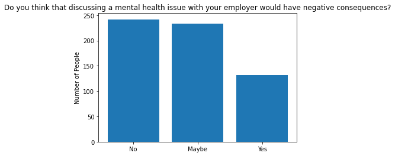

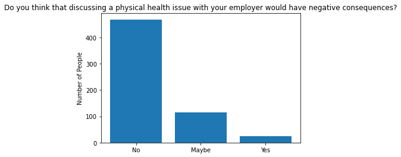

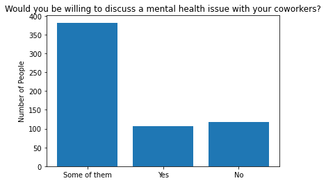

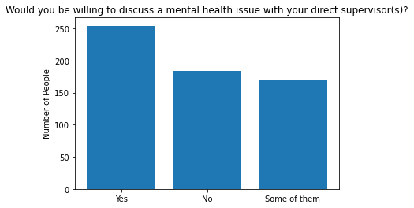

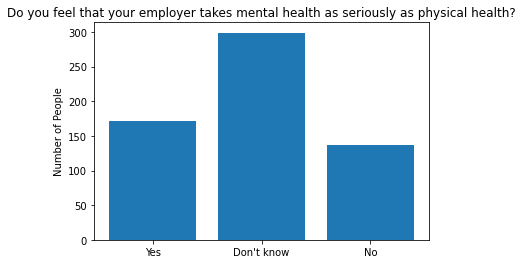

```python
for i in range(0,5):
    barGraphGeneral(titles[i], x_columns[i], "Number of People")
```

### Data Representation: Female vs. Male

In order to look at our survey answers in more detail, it would be of interest to see if there are differences between answers from male and female participants. In order to compare male and female participants, we will use a pie chart to show that percentage of answers to each question for males seperately from females. We will also put these two pie charts next to each other for each question to make analysis of the differences in the two pie charts easier.

In order to generate our pie chart, we will use matplotlib's **pie()** function. (Documentation can be found here: https://matplotlib.org/3.1.1/api/_as_gen/matplotlib.pyplot.pie.html)

As a note, because only a small fraction of people said they identified as "trans", and the sample size is too small to be reflective of the general population of trans people, we will not be looking at trans participants in our comparisons of genders.

As another note, below we look at the number of survey participants under each gender category (male, female, trans). We can notice that the population of males is much larger than the population of females. We also can see that the number of trans people is also extremely small in comparison to the number of males and females.

```python
us_tech["Gender"].value_counts()
```

```
Male      461
Female    140
Trans       6
Name: Gender, dtype: int64
```

Like with the bar graphs created earlier when looking at the general population, making pie charts could make for writing a lot of repetitive code if we were to make a pie chart seperate for each question. Therefore, we will attempt to write a function that can take in the question as a parameter, and make a pie chart comparing male and females for the specifie question. Such a function is shown below:

```python
#Function for comparing the men and women answers for a specific question
def pieCompareGenderPercentages(title, x_column_name):

    #Getting data for female survey participants
    female_dataframe = us_tech[us_tech["Gender"] == "Female"]
    count_female = female_dataframe[x_column_name].value_counts()
    percentage_female = (count_female/us_tech["Gender"].value_counts()["Female"])*100
    count_and_percentage_female = pd.concat([count_female, percentage_female], axis = 1, keys = ["Count", "Percentage"])

    #Getting data for male survey participants
    male_dataframe = us_tech[us_tech["Gender"] == "Male"]
    count_male = male_dataframe[x_column_name].value_counts()
    percentage_male = (count_male/us_tech["Gender"].value_counts()["Male"])*100
    count_and_percentage_male = pd.concat([count_male, percentage_male], axis = 1, keys = ["Count", "Percentage"])

    fig = plt.figure(figsize=(4,3),dpi=144)

    #Adding pie chart for male data
    ax2 = fig.add_subplot(121)
    ax2.pie(percentage_male, labels = male_dataframe[x_column_name].unique(), autopct='%1.1f%%', startangle=90, radius = 1.2)
    ax2.axis('equal')
    ax2.set_title("Male", y = 0)

    #Adding pie chart for female data
    ax1 = fig.add_subplot(122)
    ax1.pie(percentage_female, labels = female_dataframe[x_column_name].unique(), autopct='%1.1f%%', startangle=90, radius = 1.2)
    ax1.axis('equal')
    ax1.set_title("Female", y = 0)

    fig.suptitle(title)

    plt.show()
```

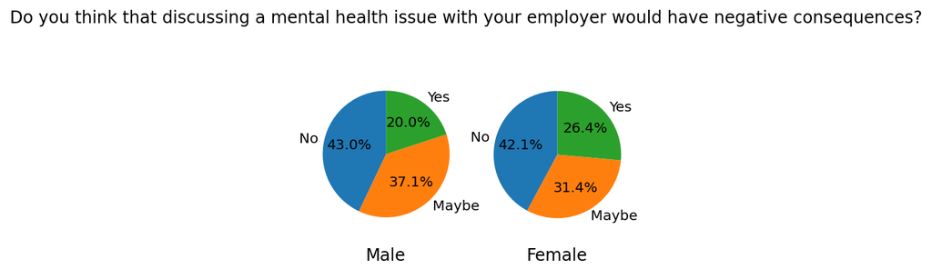

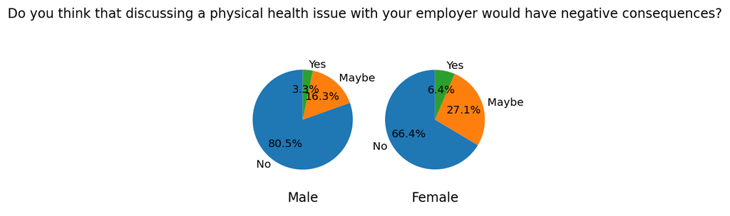

[figure not shown]

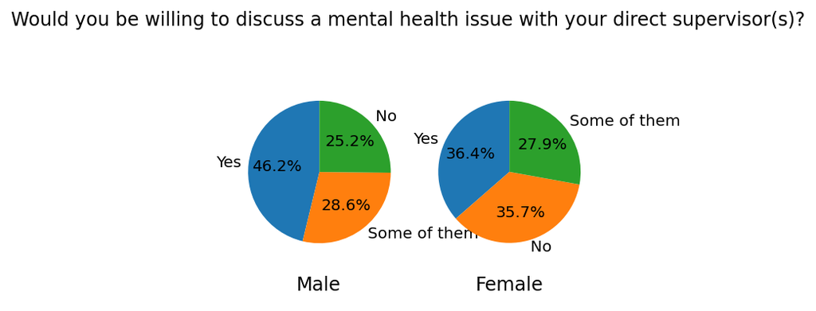

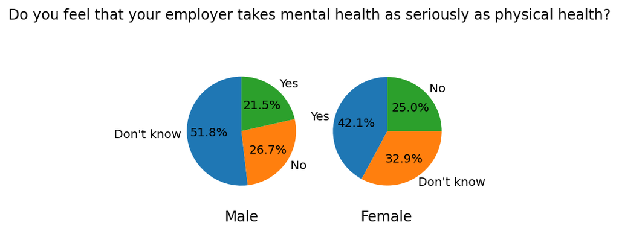

```python
for i in range(0,5):
    pieCompareGenderPercentages(titles[i],x_columns[i])
```

# Machine Learning: Can we predict whether a person in the tech industry has undergone treatment for mental health?

In the dataset, there is a column labeled "treatment", where patients answered the question "Have you sought treatment for a mental health condition?". As there are other answered questions such as "Do you have a family history of mental illness?", "How many employees does your company or organization have?", etc, it would be of interest to see whether or not these other answered questions (in otherwords, other "factors") can predict whether or an employee has sought treatment. To do this, we will attempt to use a model to "fit" the data. In this case, to "fit" the data means to use a given model to have it predict values as accurately as possible.

## What models will we use?

In order to obtain our models, we will use sklearn's linear_model module for **Logistic Regression**. We will also be using sklearn's **DecisionTreeClassifier** from the tree module, as well as sklearn's **RandomForestClassifier** from the ensemble module.

Documentation for these models can be found here:  
Linear Regression: https://scikit-learn.org/stable/modules/generated/sklearn.linear_model.LinearRegression.html  
Decision Tree: https://scikit-learn.org/stable/modules/generated/sklearn.tree.DecisionTreeClassifier.html  
Random Forest: https://scikit-learn.org/stable/modules/generated/sklearn.ensemble.RandomForestClassifier.html

```python
from sklearn.model_selection import train_test_split
from sklearn.linear_model import LogisticRegression
from sklearn.tree import DecisionTreeClassifier
from sklearn.ensemble import RandomForestClassifier
from sklearn.neighbors import KNeighborsClassifier
from sklearn.model_selection import cross_val_score
from sklearn import metrics
from sklearn.metrics import accuracy_score
from sklearn.model_selection import train_test_split
from sklearn import preprocessing
from sklearn.datasets import make_classification
from sklearn.preprocessing import binarize, LabelEncoder, MinMaxScaler
from sklearn import model_selection
```

```python
#Need to change the values in each of the columns to corresponding numerical values.
#To do this will use the LabelEncoder

train_us_tech = us_tech

#Dropping the "comments", "work_interfere", "state", and "self_employed" columns because will not be relevant to our training
train_us_tech = train_us_tech.drop(['comments'], axis=1)
train_us_tech = train_us_tech.drop(['state'], axis=1)
train_us_tech = train_us_tech.drop(['work_interfere'], axis=1)
train_us_tech = train_us_tech.drop(['self_employed'], axis=1)

#Dictionary for our labels
dict_for_labels = {}

for feat in train_us_tech:

    #Generating labels for dataset using sklearn's label encoder.
    #See here for documentation of LabelEncoder: https://scikit-learn.org/stable/modules/generated/sklearn.preprocessing.LabelEncoder.html

    labenc = preprocessing.LabelEncoder()
    labenc.fit(train_us_tech[feat])
    labencnm = dict(zip(labenc.classes_, labenc.transform(labenc.classes_)))

    #Transforming the non-numberical labels to numerical labels
    train_us_tech[feat] = labenc.transform(train_us_tech[feat])

    #Retrieving the labels
    lk =  feat
    lv = [*labencnm]
    dict_for_labels[lk] =lv

#Get rid of country column (because only looking at the US)
train_us_tech = train_us_tech.drop(['Country'], axis= 1)

#Displaying dataframe which now has numerical values representing each answer/label given
train_us_tech.head()
```

|  | Timestamp | Age | Gender | family_history | treatment | no_employees | remote_work | tech_company | benefits | care_options | ... | anonymity | leave | mental_health_consequence | phys_health_consequence | coworkers | supervisor | mental_health_interview | phys_health_interview | mental_vs_physical | obs_consequence |
| --- | --- | --- | --- | --- | --- | --- | --- | --- | --- | --- | --- | --- | --- | --- | --- | --- | --- | --- | --- | --- | --- |
| 0 | 0 | 19 | 0 | 0 | 1 | 4 | 0 | 0 | 2 | 1 | ... | 2 | 2 | 1 | 1 | 1 | 2 | 1 | 0 | 2 | 0 |
| 4 | 1 | 13 | 1 | 0 | 0 | 1 | 1 | 0 | 2 | 0 | ... | 0 | 0 | 1 | 1 | 1 | 2 | 2 | 2 | 0 | 0 |
| 5 | 2 | 15 | 1 | 1 | 0 | 4 | 0 | 0 | 2 | 1 | ... | 0 | 0 | 1 | 1 | 2 | 2 | 1 | 0 | 0 | 0 |
| 6 | 3 | 17 | 0 | 1 | 1 | 0 | 1 | 0 | 1 | 0 | ... | 1 | 1 | 0 | 0 | 1 | 0 | 1 | 1 | 0 | 0 |
| 8 | 4 | 24 | 0 | 1 | 1 | 1 | 0 | 0 | 2 | 2 | ... | 1 | 3 | 0 | 1 | 2 | 2 | 1 | 0 | 1 | 0 |

5 rows × 22 columns

```python
X = train_us_tech[feature_cols]
Y = train_us_tech.treatment

X_train, X_test, Y_train, Y_test = train_test_split(X, Y, test_size=0.25, random_state=0)


def logReg():
    logisticRegressionFunc = LogisticRegression(C=60)
    logisticRegressionFunc.fit(X_train, Y_train)
    Y_predict = logisticRegressionFunc.predict(X_test)

    #The accuracy score is the percent of predications that were correct
    acc = metrics.accuracy_score(Y_test, Y_predict)

    print("Accuracy score for logistic regression: " + str(acc*100))
    print("Classification error for logistic regression: " + str((1-acc)*100))
```

```python
logReg()
```

```
Accuracy score for logistic regression: 75.6578947368421
Classification error for logistic regression: 24.342105263157897
```

```python
kf = model_selection.KFold(n_splits=10)
cv_for_random_forest = cross_val_score(RandomForestClassifier(), X, Y, cv=kf, scoring='accuracy')
cv_for_random_forest_mean = cv_for_random_forest.mean()
cv_for_random_forest_std = cv_for_random_forest.std()
cv_for_decision_tree = cross_val_score(DecisionTreeClassifier(), X, Y, cv=kf, scoring='accuracy')
cv_for_decision_tree_mean = cv_for_decision_tree.mean()
cv_for_decision_tree_std = cv_for_decision_tree.std()
random_forest_print_stm = "The cross validation score for the Random Forest" +" algorithm used was: " + str(cv_for_random_forest_mean) + " with a standard deviation of " + str(cv_for_random_forest_std) +"."
decision_tree_print_stm = "The cross validation score for the Classification and Regression Tree" +" algorithm used was: " + str(cv_for_decision_tree_mean) + " with a standard deviation of " + str(cv_for_decision_tree_std) +"."
print(random_forest_print_stm)
print(decision_tree_print_stm)
```

```
The cross validation score for the Random Forest algorithm used was: 0.6639344262295083 with a standard deviation of 0.05726804634308539.
The cross validation score for the Classification and Regression Tree algorithm used was: 0.634071038251366 with a standard deviation of 0.06245856818966302.
```

# Insight and Company Policy Decisions

**From these insights, we can make a few suggestions about how tech companies in the United States can do better to help workers when it comes to mental health:**  
1. As quite a lot of workers do not konw their companies stance on mental health, companies should consider making it a point ot educate their workers on the mental health resources they have for their workers to utilize. In addition, if they do not have mental health resources available, they should implement programs to help workers with mental health.  
2. Individual managers should also consider talking to their workers during one-on-one meetings (perhaps during onboarding or during the start of working at the company) to inform them on where they stand on mental health, and whether or not they are willing to be a resource to the workers.

Overall, this data and analysis can be used by companies to understand how they are percieved by workers in regards to mental health, and also to figure out what policies may be needed to be implemented in order to make for more positive working environments.